# DM manipulation statistique avec R

XinChen22105822

12/10/2021

## 1. Installation des packages

```r
requiredPackages = c('tidyverse', 'languageR', 'Hmisc', 'corrplot', 'broom', 'knitr', 'xtable', 'ggsignif')
for(p in requiredPackages){
  if(!require(p,character.only = TRUE)) install.packages(p)
  library(p,character.only = TRUE)
}
```

## 2. Iris {datasets}

```r
data("iris")
iris %>%
  View()
help("iris")
```

```
## starting httpd help server ... done
```

## 3.Description statistiques

Edgar Anderson’s Iris Data est une base de données qui porte sur 50 fleurs de 3 espèces d’iris dont les mesures(en longueur et en largeur) des sépals et des pétales sont données. Le format d’Iris est un dataframe de 150 cellules et de 5 variables(colonnes) “Sepal.Length, Sepal.Width, Petal.Length, Petal.Width, Species”.

Les vaiables

```r
iris %>%
  group_by(Species) %>%
  summary()
```

```
##   Sepal.Length    Sepal.Width     Petal.Length    Petal.Width
##  Min.   :4.300   Min.   :2.000   Min.   :1.000   Min.   :0.100
##  1st Qu.:5.100   1st Qu.:2.800   1st Qu.:1.600   1st Qu.:0.300
##  Median :5.800   Median :3.000   Median :4.350   Median :1.300
##  Mean   :5.843   Mean   :3.057   Mean   :3.758   Mean   :1.199
##  3rd Qu.:6.400   3rd Qu.:3.300   3rd Qu.:5.100   3rd Qu.:1.800
##  Max.   :7.900   Max.   :4.400   Max.   :6.900   Max.   :2.500
##        Species
##  setosa    :50
##  versicolor:50
##  virginica :50
##
##
##
```

Dataframe

```r
str(iris)
```

```
## 'data.frame':    150 obs. of  5 variables:
##  $ Sepal.Length: num  5.1 4.9 4.7 4.6 5 5.4 4.6 5 4.4 4.9 ...
##  $ Sepal.Width : num  3.5 3 3.2 3.1 3.6 3.9 3.4 3.4 2.9 3.1 ...
##  $ Petal.Length: num  1.4 1.4 1.3 1.5 1.4 1.7 1.4 1.5 1.4 1.5 ...
##  $ Petal.Width : num  0.2 0.2 0.2 0.2 0.2 0.4 0.3 0.2 0.2 0.1 ...
##  $ Species     : Factor w/ 3 levels "setosa","versicolor",..: 1 1 1 1 1 1 1 1 1 1 ...
```

## 4.Manipuler la base de données

i.changer la valeur de référence

```r
levels(iris$Species)
```

```
## [1] "setosa"     "versicolor" "virginica"
```

```r
iris_df<- iris %>%
  mutate(Species  = fct_relevel(Species , "versicolor"))
levels(iris$Species)
```

```
## [1] "setosa"     "versicolor" "virginica"
```

2. selectionner et filtrer les variables

```r
iris %>%
  select(Sepal.Length, Sepal.Width, Species) %>%
  filter(Species == "setosa")
```

```
##    Sepal.Length Sepal.Width Species
## 1           5.1         3.5  setosa
## 2           4.9         3.0  setosa
## 3           4.7         3.2  setosa
## 4           4.6         3.1  setosa
## 5           5.0         3.6  setosa
## 6           5.4         3.9  setosa
## 7           4.6         3.4  setosa
## 8           5.0         3.4  setosa
## 9           4.4         2.9  setosa
## 10          4.9         3.1  setosa
## 11          5.4         3.7  setosa
## 12          4.8         3.4  setosa
## 13          4.8         3.0  setosa
## 14          4.3         3.0  setosa
```

[output cut: 36 more lines]

iii.résumés des données (général vs spécifique)

```r
summary(iris)
```

```
##   Sepal.Length    Sepal.Width     Petal.Length    Petal.Width
##  Min.   :4.300   Min.   :2.000   Min.   :1.000   Min.   :0.100
##  1st Qu.:5.100   1st Qu.:2.800   1st Qu.:1.600   1st Qu.:0.300
##  Median :5.800   Median :3.000   Median :4.350   Median :1.300
##  Mean   :5.843   Mean   :3.057   Mean   :3.758   Mean   :1.199
##  3rd Qu.:6.400   3rd Qu.:3.300   3rd Qu.:5.100   3rd Qu.:1.800
##  Max.   :7.900   Max.   :4.400   Max.   :6.900   Max.   :2.500
##        Species
##  setosa    :50
##  versicolor:50
##  virginica :50
##
##
##
```

```r
iris %>%
  group_by(Species) %>%
  summarise(count = n(),
            range_Petal.Length = range(Petal.Length),
            mean_Petal.Length = mean(Petal.Length),
            sd_Petal.Length = sd(Petal.Length),
            var_Petal.Length = var(Petal.Length),
            min_Petal.Length = min(Petal.Length),
            max_Petal.Length = max(Petal.Length),
            median_Petal.Length = median(Petal.Length))
```

```
## # A tibble: 6 x 9
## # Groups:   Species [3]
##   Species    count range_Petal.Length mean_Petal.Length sd_Petal.Length
##   <fct>      <int>              <dbl>             <dbl>           <dbl>
## 1 setosa        50                1                1.46           0.174
## 2 setosa        50                1.9              1.46           0.174
## 3 versicolor    50                3                4.26           0.470
## 4 versicolor    50                5.1              4.26           0.470
## 5 virginica     50                4.5              5.55           0.552
## 6 virginica     50                6.9              5.55           0.552
## # ... with 4 more variables: var_Petal.Length <dbl>, min_Petal.Length <dbl>,
## #   max_Petal.Length <dbl>, median_Petal.Length <dbl>
```

## 5.Hypothèse

A partir de l’observation sur les données, en particulier le résumé statistique de données par groupes d’espèces, on peut formuler l’hypothèse tel que les variations morphologiques des fleurs d’iris de trois espèces peuvent être quantifié, à savoir que les trois espèces peuvent être discriminé avec des méthodes statistiques. (Si on a les mésures sur les pétales d’une fleur d’iris, on peut prédire leurs espèce avec des méthodes discriminatoires)

i.Premièrement pour tester l’hypothèse, on va construire un modèle linéaire à partir d’un variable dépendant(La longueur de pétales) et le variable indépendant(espèces).

```r
mdl.lm <- iris %>%
  lm( Petal.Length ~ Species, data = .)

kable(summary(mdl.lm)$coef, digits = 3)
```

|  | Estimate | Std. Error | t value | Pr(>\|t\|) |
| --- | --- | --- | --- | --- |
| (Intercept) | 1.462 | 0.061 | 24.023 | 0 |
| Speciesversicolor | 2.798 | 0.086 | 32.510 | 0 |
| Speciesvirginica | 4.090 | 0.086 | 47.521 | 0 |

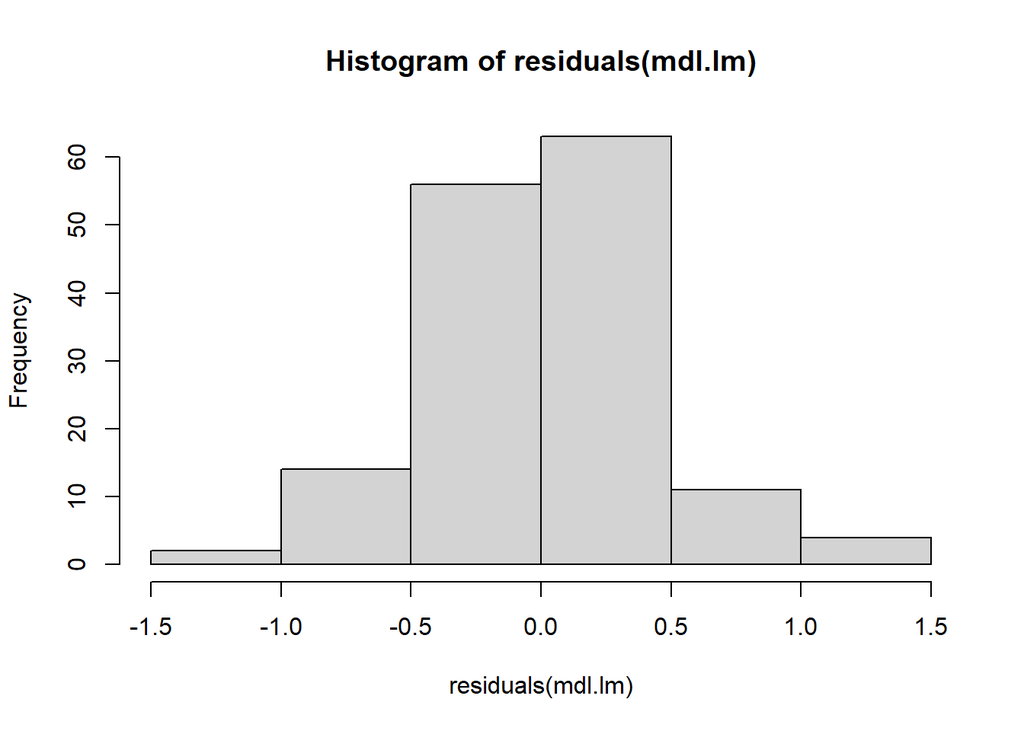

```r
hist(residuals(mdl.lm))
```

A partir du modèle linéar obtenu, on peut concluer qu’il y a bien une différence importance de la longueur de pétales entre les éspèces. Cependant, est-ce que cette conclusion peut être généralisé pour la largeur de pétales?

En fait, on peut facilement visualiser la réponse à cette question avec les plots linéaires.

## 6.La visualisation

a.Petal.Length vs Petal.Width

[figure not shown]

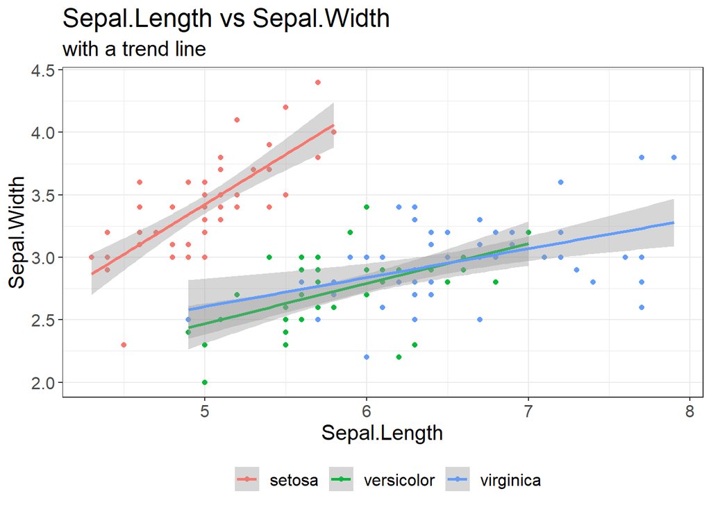

```r
iris %>%
  ggplot(aes(x = Sepal.Length,
             y = Sepal.Width,
             colour = Species)) +
  theme_bw() +
  geom_point()+
  geom_smooth(method = "lm")+
  labs(x = "Sepal.Length", y = "Sepal.Width", title = "Sepal.Length vs Sepal.Width", subtitle = "with a trend line") + # add labels
  theme(text = element_text(size = 15)) + # increase size of plot
  theme(legend.position = "bottom", legend.title = element_blank())  # remove legend title and change position
```

1.Les deux plots(a, b) montre que l’hypothése est prouvé vrai.C’est à dire que si on a les mésures sur les pétales d’une fleur d’iris, on peut prédire leurs espèce avec des méthodes discriminatoires (ses mésures de pétales tombes dans quel groupe d’espèces)

2.à partir de plot a, on voit que la discrimination entre les trois espèces est la plus important lors qu’on prend en compte les mésures de pétals(“Length” et “Width”)

3.à partir de plot b, on voit que la différence entre les espèces est plutôt flou lors qu’on compare les sépales.

## 7. L’Analyse inférentielle

```r
cor(iris$Petal.Length, iris$Petal.Width, method = "pearson")
```

```
## [1] 0.9628654
```

```r
cor.test(iris$Petal.Length, iris$Petal.Width)
```

```
##
##  Pearson's product-moment correlation
##
## data:  iris$Petal.Length and iris$Petal.Width
## t = 43.387, df = 148, p-value < 2.2e-16
## alternative hypothesis: true correlation is not equal to 0
## 95 percent confidence interval:
##  0.9490525 0.9729853
## sample estimates:
##       cor
## 0.9628654
```

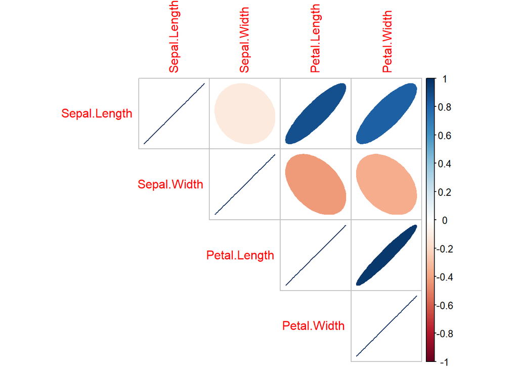

```r
corr <-
  iris %>%
  select(where(is.numeric)) %>%
  cor()

corrplot(corr, method = 'ellipse', type = 'upper')
```

## 8.Conclusion:

La base de données “iris” a présenté un modèle statistique pour differencier les espèces d’iris. Si on a les mésures sur les pétales(et les sepals?)d’une fleur d’iris, on peut prédire leurs espèce avec des méthodes discriminatoires.